# Pollutants and Weather Variables in Madrid

Group H

### (A) Getting source files

##### Loading of source files to get acccess to helper functions

```r
source('projectfunctions.R')
```

### (B) Importing necessary packages/libraries

```r
## Get data.table package if not installed
if(!"data.table" %in% installed.packages()) {
  install.packages("data.table")
} else {
  print('data.table package already installed')
}
```

```
## [1] "data.table package already installed"
```

```r
library(data.table)
## Get ggplot if not installed
if(!"ggplot2" %in% installed.packages()) {
  install.packages("ggplot2")
} else {
  print('ggplot2 package already installed')
}
```

```
## [1] "ggplot2 package already installed"
```

```r
library(ggplot2)

## Get readxl package if not installed
if(!"readxl" %in% installed.packages()) {
  install.packages("readxl")
} else {
  print('readxl package already installed')
}
```

```
## [1] "readxl package already installed"
```

```r
library(readxl)

## Get corrplot package if not installed
if(!"corrplot" %in% installed.packages()) {
  install.packages("corrplot")
} else {
  print('corrplot package already installed')
}
```

```
## [1] "corrplot package already installed"
```

```r
library(corrplot)
## Get dygraph package if not installed
if(!"dygraphs" %in% installed.packages()) {
  install.packages("dygraphs")
} else {
  print('dygraphs package already installed')
}
```

```
## [1] "dygraphs package already installed"
```

```r
library(dygraphs)

## Get shiny package if not installed
if(!"shiny" %in% installed.packages()) {
  install.packages("shiny")
} else {
  print('shiny package already installed')
}
```

```
## [1] "shiny package already installed"
```

```r
library(shiny)

## Get dplyr package if not installed
if(!"dplyr" %in% installed.packages()) {
  install.packages("dplyr")
} else {
  print('dplyr package already installed')
}
```

```
## [1] "dplyr package already installed"
```

```r
library(dplyr)
```

```r
## Get d3heatmap package if not installed
if(!"d3heatmap" %in% installed.packages()) {
  install.packages("d3heatmap")
} else {
  print('d3heatmap package already installed')
}
```

```
## [1] "d3heatmap package already installed"
```

```r
library(d3heatmap)

## Get xts package if not installed
if(!"xts" %in% installed.packages()) {
  install.packages("xts")
} else {
  print('xts package already installed')
}
```

```
## [1] "xts package already installed"
```

```r
library(xts)
## Get leaflet package if not installed
if(!"leaflet" %in% installed.packages()) {
  install.packages("leaflet")
} else {
  print('leaflet package already installed')
}
```

```
## [1] "leaflet package already installed"
```

```r
library(leaflet)
```

### (C) Defining Constants to be used throughout script

###### This was used for faster testing

```r
years <- 11:16
months <- 1:12
```

### (D) Load data

#### 1) Load raw_data (whole initial data set for pollutants) from hourly data sets

```r
raw_data <- readAllHourlyDataCSVs(years, months)
print(readAllHourlyDataCSVs)
```

```
## function (years, months)
## {
##     hourlyPollutants <- data.frame()
##     for (year in years) {
##         for (month in months) {
##             monthlyData <- readHourlyDataCSV(year, month)
##             hourlyPollutants <- rbind(hourlyPollutants, monthlyData)
##         }
##     }
##     return(hourlyPollutants)
## }
## <bytecode: 0x7fd76c17e5b8>
```

```r
print(readHourlyDataCSV)
```

```
## function (year, month)
## {
##     fileName <- paste0("hourly_data_", year, "_", month, ".csv")
##     csvContents <- read.csv(fileName)
##     csvContents$station <- as.factor(csvContents$station)
##     csvContents$parameter <- as.factor(csvContents$parameter)
##     csvContents$date <- as.Date(paste0("20", year, "-", month,
##         "-", csvContents$day))
##     csvContents$day <- NULL
##     return(csvContents)
## }
## <bytecode: 0x7fd76c381968>
```

```r
head(raw_data)
```

```
##   hour  station parameter value       date
## 1    1 28079004         1     6 2011-01-01
## 2    1 28079008         1    12 2011-01-01
## 3    1 28079017         1    12 2011-01-01
## 4    1 28079018         1    10 2011-01-01
## 5    1 28079024         1     7 2011-01-01
## 6    1 28079035         1    11 2011-01-01
```

#### 2) Get pollutants names and merge with raw_data

```r
pollutant_names <- getPollutantNames();
raw_data  <- merge(raw_data, pollutant_names, by.x='parameter', by.y='parameter')
head(raw_data)
```

```
##   parameter hour  station value       date formula
## 1         1    1 28079004     6 2011-01-01     SO2
## 2         1    1 28079008    12 2011-01-01     SO2
## 3         1    1 28079017    12 2011-01-01     SO2
## 4         1    1 28079018    10 2011-01-01     SO2
## 5         1    1 28079024     7 2011-01-01     SO2
## 6         1    1 28079035    11 2011-01-01     SO2
```

#### 3) Average hourly pollutant data to get one mean value per day, per pollutant

```r
raw_data_table <- data.table(raw_data)
avgByParameterAndDate <- raw_data_table[,.(mean_value=mean(value,na.rm=T)), by=list(formula, date)]
head(avgByParameterAndDate)
```

```
##    formula       date mean_value
## 1:     SO2 2011-01-01  10.712500
## 2:     SO2 2011-03-29   6.916667
## 3:     SO2 2016-11-26   8.328704
## 4:     SO2 2016-03-31   8.705882
## 5:     SO2 2011-04-27   6.141667
## 6:     SO2 2014-12-03   8.375000
```

#### 4) Dcast into tabular format

```r
allPollutantDataByDate <- dcast(avgByParameterAndDate, date~formula)
head(allPollutantDataByDate)
```

```
##          date       BEN        CO       EBE      NMHC       NO      NO2
## 1: 2011-01-01 0.7652778 0.3725000 0.5951389 0.1865833 16.53819 41.51042
## 2: 2011-01-02 0.8687500 0.4529167 0.7215278 0.2076667 28.82292 48.47396
## 3: 2011-01-03 1.1756944 0.5325000 1.0472222 0.2457500 71.14236 63.63368
## 4: 2011-01-04 0.8569444 0.3670833 0.7881944 0.1955833 27.82639 46.29514
## 5: 2011-01-05 0.8562500 0.3950000 1.0736111 0.1960833 36.02951 51.51736
## 6: 2011-01-06 0.5263889 0.2854167 0.6041667 0.1646667 11.19271 35.32812
##           O3      PM10     PM2.5       SO2      TCH      TOL
## 1: 20.473214 13.831579  9.363636 10.712500 1.432167 1.663889
## 2: 15.562500 13.656250  9.076389 11.933333 1.624833 2.138889
## 3:  9.446429 21.555556 11.944444 11.912134 1.621250 3.564583
## 4: 13.342262 14.357639  9.402778  8.841667 1.456417 2.395139
## 5: 10.883929 15.597222 10.513889  9.508403 1.515833 3.193056
## 6: 23.419643  9.753472  6.979167  8.633333 1.472917 1.713194
```

#### 5) Get daily weather data from excel file

```r
weather <- getWeatherData()
print(getWeatherData)
```

```
## function ()
## {
##     weatherData <- read_excel("weather.xlsx")
##     weatherData <- as.data.frame(weatherData)
##     weatherData$date <- as.Date(weatherData$date)
##     return(weatherData)
## }
```

```r
head(weather)
```

```
##         date temp_avg temp_max temp_min precipitation humidity
## 1 2011-01-01      8.3     13.0      3.0          0.00       84
## 2 2011-01-02      8.6     13.0      4.0          0.00       81
## 3 2011-01-03      4.2      9.4     -1.6          0.00       86
## 4 2011-01-04      6.5      8.0      4.1          0.00       93
## 5 2011-01-05      8.9     10.0      6.3          0.00       90
## 6 2011-01-06     12.2     15.0      8.9          0.51       87
##   wind_avg_speed
## 1            5.2
## 2            5.4
## 3            3.5
## 4            6.3
## 5           10.4
## 6           15.7
```

#### 6) Add weather data to tabular pollutant data

```r
allPollutantDataByDate <- as.data.frame(allPollutantDataByDate)
avgByParameterAndDateWeather <- merge(allPollutantDataByDate, weather, by.x='date', by.y='date')
head(avgByParameterAndDateWeather)
```

```
##         date       BEN        CO       EBE      NMHC       NO      NO2
## 1 2011-01-01 0.7652778 0.3725000 0.5951389 0.1865833 16.53819 41.51042
## 2 2011-01-02 0.8687500 0.4529167 0.7215278 0.2076667 28.82292 48.47396
## 3 2011-01-03 1.1756944 0.5325000 1.0472222 0.2457500 71.14236 63.63368
## 4 2011-01-04 0.8569444 0.3670833 0.7881944 0.1955833 27.82639 46.29514
## 5 2011-01-05 0.8562500 0.3950000 1.0736111 0.1960833 36.02951 51.51736
## 6 2011-01-06 0.5263889 0.2854167 0.6041667 0.1646667 11.19271 35.32812
##          O3      PM10     PM2.5       SO2      TCH      TOL temp_avg
## 1 20.473214 13.831579  9.363636 10.712500 1.432167 1.663889      8.3
## 2 15.562500 13.656250  9.076389 11.933333 1.624833 2.138889      8.6
## 3  9.446429 21.555556 11.944444 11.912134 1.621250 3.564583      4.2
## 4 13.342262 14.357639  9.402778  8.841667 1.456417 2.395139      6.5
## 5 10.883929 15.597222 10.513889  9.508403 1.515833 3.193056      8.9
## 6 23.419643  9.753472  6.979167  8.633333 1.472917 1.713194     12.2
##   temp_max temp_min precipitation humidity wind_avg_speed
## 1     13.0      3.0          0.00       84            5.2
## 2     13.0      4.0          0.00       81            5.4
## 3      9.4     -1.6          0.00       86            3.5
## 4      8.0      4.1          0.00       93            6.3
## 5     10.0      6.3          0.00       90           10.4
## 6     15.0      8.9          0.51       87           15.7
```

#### 7) Get monthly average data set

```r
monthlyAvgPollutantsAndWeather <- getMonthlyAverages(avgByParameterAndDateWeather)
print(getMonthlyAverages)
```

```
## function (dataFrame)
## {
##     dataFrame$month = format(dataFrame$date, "%m")
##     dataFrame$year = format(dataFrame$date, "%Y")
##     aggregatedDataFrame = aggregate(dataFrame[, !colnames(dataFrame) %in%
##         c("year", "month", "date")], FUN = mean, by = list(month = dataFrame$month,
##         year = dataFrame$year))
##     aggregatedDataFrame$date = as.Date(paste0(aggregatedDataFrame$year,
##         "-", aggregatedDataFrame$month, "-01"))
##     return(aggregatedDataFrame)
## }
## <bytecode: 0x7fd76b37a728>
```

```r
head(monthlyAvgPollutantsAndWeather)
```

```
##   month year       BEN        CO       EBE      NMHC       NO      NO2
## 1    01 2011 1.1848303 0.4839570 1.1693323 0.2180107 49.48546 55.62606
## 2    02 2011 1.1398151 0.4891834 1.2325172 0.2234144 53.72857 61.47513
## 3    03 2011 0.7828510 0.3467943 0.8061466 0.1912855 15.84214 40.92034
## 4    04 2011 0.6353850 0.3085128 0.9665323 0.1989766 15.20836 40.03295
## 5    05 2011 0.5085527 0.2466257 0.8072045 0.1829694 10.91002 36.51002
## 6    06 2011 0.5801251 0.2721401 0.8256712 0.1703991 10.84499 37.13810
##         O3     PM10    PM2.5       SO2      TCH      TOL  temp_avg
## 1 21.27811 20.07836 12.14664 11.793511 1.485970 3.850144  5.822581
## 2 29.50399 23.69177 13.19186 10.968964 1.404108 3.944818  7.571429
## 3 49.48116 18.84727 10.34350  8.263827 1.386874 2.393199  9.751613
## 4 59.88537 27.29717 13.48194  6.648996 1.423277 2.984380 15.706667
## 5 59.43430 20.15732 11.11499  6.147337 1.416648 2.739355 18.606452
## 6 65.59912 23.87488 12.33915  6.244846 1.382979 2.846971 23.010000
##   temp_max  temp_min precipitation humidity wind_avg_speed       date
## 1 10.68065  1.622581     0.8441935 78.70968       7.406452 2011-01-01
## 2 14.66071  1.296429     0.4078571 65.71429      10.128571 2011-02-01
## 3 14.93226  4.509677     1.2529032 67.29032      10.400000 2011-03-01
## 4 22.64667  8.906667     1.5073333 59.50000       8.870000 2011-04-01
## 5 25.30323 11.529032     1.7861290 56.93548       8.903226 2011-05-01
## 6 30.12333 14.303333     1.1006667 40.40000       9.493333 2011-06-01
```

#### 8) Generate yearly average pollutant dataset by station

```r
raw_data_table$year = format(raw_data_table$date, '%Y')
yearlyAveragesPollutantByStation <- raw_data_table[,.(mean_value=mean(value,na.rm=T)), by=list(station, year,formula)]
head(yearlyAveragesPollutantByStation)
```

```
##     station year formula mean_value
## 1: 28079004 2011     SO2   7.033223
## 2: 28079008 2011     SO2   7.017374
## 3: 28079017 2011     SO2   6.529425
## 4: 28079018 2011     SO2   5.877572
## 5: 28079024 2011     SO2   4.985650
## 6: 28079035 2011     SO2   8.807203
```

##### 9) Get station details from stations csv

###### Source of data: https://www.kaggle.com/decide-soluciones/air-quality-madrid

```r
stationDetails = read.csv('stations.csv')
stationDetails$id = as.factor(stationDetails$id)
head(stationDetails)
```

```
##         id                name
## 1 28079004      Pza. de España
## 2 28079008    Escuelas Aguirre
## 3 28079011 Avda. Ramón y Cajal
## 4 28079016        Arturo Soria
## 5 28079017          Villaverde
## 6 28079018           Farolillo
##                                             address       lon      lat
## 1                                   Plaza de España -3.712247 40.42385
## 2                   Entre C/ Alcalá y C/ O’ Donell  -3.682319 40.42156
## 3  Avda. Ramón y Cajal  esq. C/ Príncipe de Vergara -3.677356 40.45148
## 4 C/ Arturo Soria  esq. C/  Vizconde de los Asilos  -3.639233 40.44005
## 5                                 C/. Juan Peñalver -3.713322 40.34714
## 6                       Calle Farolillo - C/Ervigio -3.731853 40.39478
##   elevation
## 1       635
## 2       670
## 3       708
## 4       693
## 5       604
## 6       630
```

#### 10) Merge station locations with yearlyAveragesPollutantByStation

```r
yearlyAveragesPollutantByStation = merge(yearlyAveragesPollutantByStation, stationDetails, by.x='station', by.y='id' )
head(yearlyAveragesPollutantByStation)
```

```
##     station year formula mean_value           name         address
## 1: 28079004 2011     SO2   7.033223 Pza. de España Plaza de España
## 2: 28079004 2016     SO2   7.496011 Pza. de España Plaza de España
## 3: 28079004 2014     SO2   5.027711 Pza. de España Plaza de España
## 4: 28079004 2015     SO2   7.651860 Pza. de España Plaza de España
## 5: 28079004 2012     SO2   4.086777 Pza. de España Plaza de España
## 6: 28079004 2013     SO2   4.620165 Pza. de España Plaza de España
##          lon      lat elevation
## 1: -3.712247 40.42385       635
## 2: -3.712247 40.42385       635
## 3: -3.712247 40.42385       635
## 4: -3.712247 40.42385       635
## 5: -3.712247 40.42385       635
## 6: -3.712247 40.42385       635
```

#### 11) Summary of existing variables and data sets

##### avgByParameterAndDate

```r
str(avgByParameterAndDate)
```

```
## Classes 'data.table' and 'data.frame':   26304 obs. of  3 variables:
##  $ formula   : Factor w/ 17 levels "BEN","CH4","CO",..: 15 15 15 15 15 15 15 15 15 15 ...
##  $ date      : Date, format: "2011-01-01" "2011-03-29" ...
##  $ mean_value: num  10.71 6.92 8.33 8.71 6.14 ...
##  - attr(*, ".internal.selfref")=<externalptr>
```

##### avgByParameterAndDateWeather

```r
str(avgByParameterAndDateWeather)
```

```
## 'data.frame':    2192 obs. of  19 variables:
##  $ date          : Date, format: "2011-01-01" "2011-01-02" ...
##  $ BEN           : num  0.765 0.869 1.176 0.857 0.856 ...
##  $ CO            : num  0.372 0.453 0.532 0.367 0.395 ...
##  $ EBE           : num  0.595 0.722 1.047 0.788 1.074 ...
##  $ NMHC          : num  0.187 0.208 0.246 0.196 0.196 ...
##  $ NO            : num  16.5 28.8 71.1 27.8 36 ...
##  $ NO2           : num  41.5 48.5 63.6 46.3 51.5 ...
##  $ O3            : num  20.47 15.56 9.45 13.34 10.88 ...
##  $ PM10          : num  13.8 13.7 21.6 14.4 15.6 ...
##  $ PM2.5         : num  9.36 9.08 11.94 9.4 10.51 ...
##  $ SO2           : num  10.71 11.93 11.91 8.84 9.51 ...
##  $ TCH           : num  1.43 1.62 1.62 1.46 1.52 ...
##  $ TOL           : num  1.66 2.14 3.56 2.4 3.19 ...
##  $ temp_avg      : num  8.3 8.6 4.2 6.5 8.9 12.2 10.9 9.8 8.4 6.9 ...
##  $ temp_max      : num  13 13 9.4 8 10 15 13 13 11 8.3 ...
##  $ temp_min      : num  3 4 -1.6 4.1 6.3 8.9 8.7 7.6 6.6 5.2 ...
##  $ precipitation : num  0 0 0 0 0 ...
##  $ humidity      : num  84 81 86 93 90 87 81 88 92 91 ...
##  $ wind_avg_speed: num  5.2 5.4 3.5 6.3 10.4 15.7 15.6 14.3 6.5 7.4 ...
```

##### monthlyAvgPollutantsAndWeather

```r
str(monthlyAvgPollutantsAndWeather)
```

```
## 'data.frame':    72 obs. of  21 variables:
##  $ month         : chr  "01" "02" "03" "04" ...
##  $ year          : chr  "2011" "2011" "2011" "2011" ...
##  $ BEN           : num  1.185 1.14 0.783 0.635 0.509 ...
##  $ CO            : num  0.484 0.489 0.347 0.309 0.247 ...
##  $ EBE           : num  1.169 1.233 0.806 0.967 0.807 ...
##  $ NMHC          : num  0.218 0.223 0.191 0.199 0.183 ...
##  $ NO            : num  49.5 53.7 15.8 15.2 10.9 ...
##  $ NO2           : num  55.6 61.5 40.9 40 36.5 ...
##  $ O3            : num  21.3 29.5 49.5 59.9 59.4 ...
##  $ PM10          : num  20.1 23.7 18.8 27.3 20.2 ...
##  $ PM2.5         : num  12.1 13.2 10.3 13.5 11.1 ...
##  $ SO2           : num  11.79 10.97 8.26 6.65 6.15 ...
##  $ TCH           : num  1.49 1.4 1.39 1.42 1.42 ...
##  $ TOL           : num  3.85 3.94 2.39 2.98 2.74 ...
##  $ temp_avg      : num  5.82 7.57 9.75 15.71 18.61 ...
##  $ temp_max      : num  10.7 14.7 14.9 22.6 25.3 ...
##  $ temp_min      : num  1.62 1.3 4.51 8.91 11.53 ...
##  $ precipitation : num  0.844 0.408 1.253 1.507 1.786 ...
##  $ humidity      : num  78.7 65.7 67.3 59.5 56.9 ...
##  $ wind_avg_speed: num  7.41 10.13 10.4 8.87 8.9 ...
##  $ date          : Date, format: "2011-01-01" "2011-02-01" ...
```

##### yearlyAveragesPollutantByStation

```r
str(yearlyAveragesPollutantByStation)
```

```
## Classes 'data.table' and 'data.frame':   754 obs. of  9 variables:
##  $ station   : Factor w/ 24 levels "28079004","28079008",..: 1 1 1 1 1 1 1 1 1 1 ...
##  $ year      : chr  "2011" "2016" "2014" "2015" ...
##  $ formula   : Factor w/ 17 levels "BEN","CH4","CO",..: 15 15 15 15 15 15 3 3 3 3 ...
##  $ mean_value: num  7.03 7.5 5.03 7.65 4.09 ...
##  $ name      : Factor w/ 24 levels "Arturo Soria",..: 17 17 17 17 17 17 17 17 17 17 ...
##  $ address   : Factor w/ 24 levels " Pza. Fernández Ladreda - Avda. Oporto",..: 22 22 22 22 22 22 22 22 22 22 ...
##  $ lon       : num  -3.71 -3.71 -3.71 -3.71 -3.71 ...
##  $ lat       : num  40.4 40.4 40.4 40.4 40.4 ...
##  $ elevation : int  635 635 635 635 635 635 635 635 635 635 ...
##  - attr(*, ".internal.selfref")=<externalptr>
##  - attr(*, "sorted")= chr "station"
```

### (E) Descriptive Analysis

#### 1) Missingness Analysis of each of the datasets

```r
sapply(avgByParameterAndDate, function(var) return(sum(is.na(var))))
```

```
##    formula       date mean_value
##          0          0          0
```

```r
sapply(avgByParameterAndDateWeather, function(var) return(sum(is.na(var))))
```

```
##           date            BEN             CO            EBE           NMHC
##              0              0              0              0              0
##             NO            NO2             O3           PM10          PM2.5
##              0              0              0              0              0
##            SO2            TCH            TOL       temp_avg       temp_max
##              0              0              0              0              0
##       temp_min  precipitation       humidity wind_avg_speed
##              0              0              0              0
```

```r
sapply(monthlyAvgPollutantsAndWeather, function(var) return(sum(is.na(var))))
```

```
##          month           year            BEN             CO            EBE
##              0              0              0              0              0
##           NMHC             NO            NO2             O3           PM10
##              0              0              0              0              0
##          PM2.5            SO2            TCH            TOL       temp_avg
##              0              0              0              0              0
##       temp_max       temp_min  precipitation       humidity wind_avg_speed
##              0              0              0              0              0
##           date
##              0
```

```r
sapply(yearlyAveragesPollutantByStation, function(var) return(sum(is.na(var))))
```

```
##    station       year    formula mean_value       name    address
##          0          0          0          0          0          0
##        lon        lat  elevation
##          0          0          0
```

#### 2) Box plot for pollutant measures

##### This shows how the different measures are very disperse in terms of their measure ranges

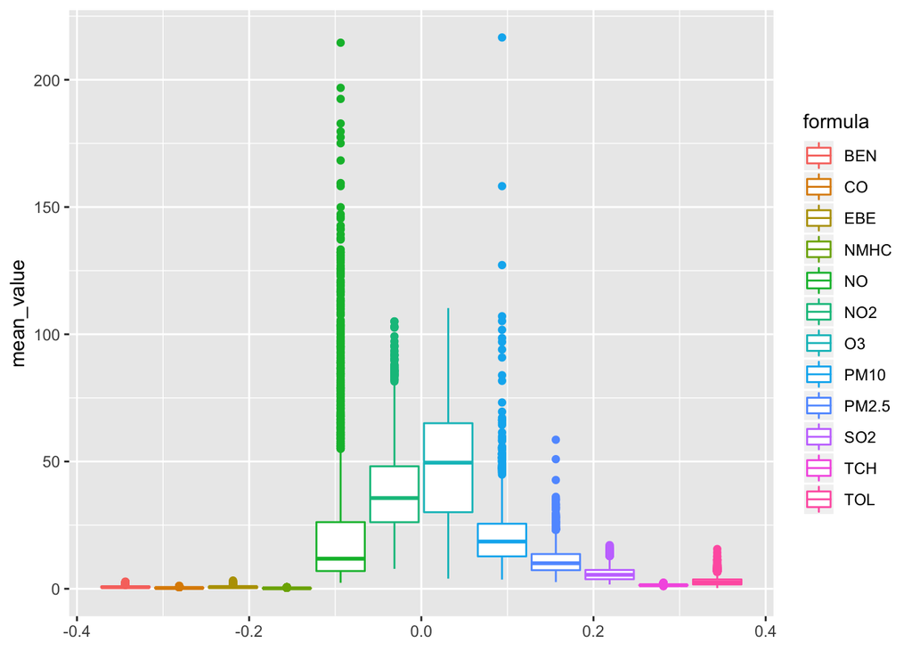

```r
ggplot(data=avgByParameterAndDate, aes(y=mean_value, colour=formula)) + geom_boxplot()
```

#### 3) Correlation Matrix

##### -Visual representation of correlations between the variables

##### -Easy to see a lot of these pollutants are correlated between each other and that there a number of highly correlated pollutants/weather measures with NO2

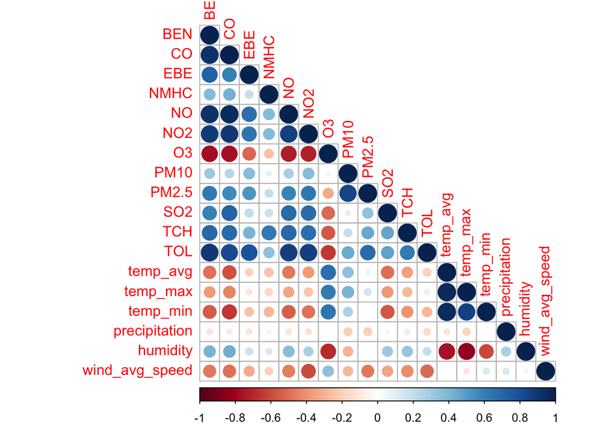

```r
correlationMatrix <- cor(avgByParameterAndDateWeather[,names(avgByParameterAndDateWeather)[sapply(avgByParameterAndDateWeather, is.numeric)]])
corrplot(correlationMatrix, method='circle', type='lower')
```

#### 4) Correlation calculation and select top most correlated

##### -To enable more detailed correlations between varibles

##### -A significant amount of varialbes are correlated with value more than .8

```r
reduced_correlation_df <- as.data.frame(as.table(correlationMatrix))
reduced_correlation_df <- reduced_correlation_df %>%  arrange(desc(Freq)) %>% filter(Freq>abs(0.8)) %>% filter(Freq!=1)
head(reduced_correlation_df, 10)
```

```
##        Var1     Var2      Freq
## 1  temp_max temp_avg 0.9685182
## 2  temp_avg temp_max 0.9685182
## 3        NO       CO 0.9511949
## 4        CO       NO 0.9511949
## 5  temp_min temp_avg 0.9503927
## 6  temp_avg temp_min 0.9503927
## 7        CO      BEN 0.9249743
## 8       BEN       CO 0.9249743
## 9        NO      BEN 0.9217097
## 10      BEN       NO 0.9217097
```

#### 5) Scatter Plots between variables that are highly correlated according to calculations above

##### We can observe a number of the highly correlated variables are POSITIVELY correlated

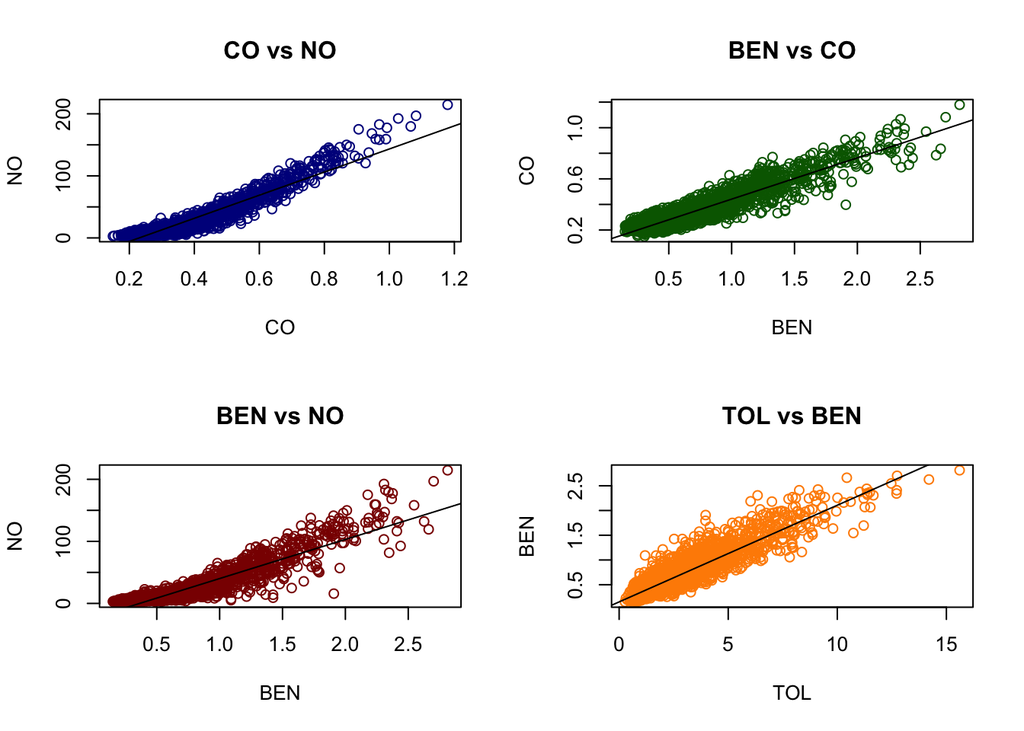

```r
par(mfrow=c(2,2))
#NO vs CO
plot(y= avgByParameterAndDateWeather$NO,x = avgByParameterAndDateWeather$CO,
     xlab='CO',ylab='NO',main = "CO vs NO", col ='darkblue')
abline(mC <- lm(NO~ CO, data = avgByParameterAndDateWeather))
#CO vs BEN
plot(y=avgByParameterAndDateWeather$CO,x=avgByParameterAndDateWeather$BEN,
     xlab='BEN',ylab='CO', main = "BEN vs CO", col = 'darkgreen')
abline(mC <- lm(CO~ BEN, data = avgByParameterAndDateWeather))
#NO vs BEN
plot(y= avgByParameterAndDateWeather$NO,x= avgByParameterAndDateWeather$BEN,
     xlab='BEN',ylab='NO', main = "BEN vs NO", col = 'darkred')
abline(mC <- lm(NO~ BEN, data = avgByParameterAndDateWeather))
#BEN vs TOL
plot(y= avgByParameterAndDateWeather$BEN,x = avgByParameterAndDateWeather$TOL,
     xlab='TOL',ylab='BEN', main = "TOL vs BEN", col = 'darkorange')
abline(mC <- lm(BEN~ TOL, data = avgByParameterAndDateWeather))
```

#### 6) Plotting the NO2 values against the measures that seem highly correlated

##### We can observe the highly correlated variables against NO2 are a combination of NEGATIVE and POSITIVE correlations

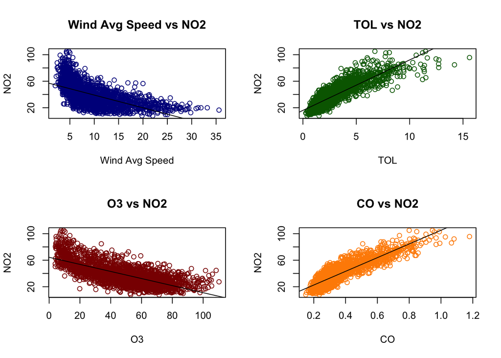

```r
par(mfrow=c(2,2))
plot(y = avgByParameterAndDateWeather$NO2,x = avgByParameterAndDateWeather$wind_avg_speed,
     xlab='Wind Avg Speed',ylab='NO2', main = "Wind Avg Speed vs NO2", col ='darkblue')
abline(mC <- lm(NO2 ~ wind_avg_speed, data = avgByParameterAndDateWeather))

plot(y = avgByParameterAndDateWeather$NO2,x = avgByParameterAndDateWeather$TOL,
     xlab='TOL',ylab='NO2', main = "TOL vs NO2", col = 'darkgreen')
abline(mC <- lm(NO2 ~ TOL, data = avgByParameterAndDateWeather))

plot(y = avgByParameterAndDateWeather$NO2,x = avgByParameterAndDateWeather$O3,
     xlab='O3',ylab='NO2', main = "O3 vs NO2", col = 'darkred')
abline(mC <- lm(NO2 ~ O3, data = avgByParameterAndDateWeather))

plot(y = avgByParameterAndDateWeather$NO2,x = avgByParameterAndDateWeather$CO,
     xlab='CO',ylab='NO2', main = "CO vs NO2", col = 'darkorange')
abline(mC <- lm(NO2 ~ CO, data = avgByParameterAndDateWeather))
```

#### 7) Comparison of pollutant measures by station

##### Using this shiny app we can explore correlations between the actual locations of the measures for different pollutant

##### We can see for example NO2 (partially caused by car emissions) much lower in park areas throughout the years

```r
### Formulate parameters
pollutantOptions <- unique(yearlyAveragesPollutantByStation$formula)
yearOptions<- paste0('20', as.character(years))

### Run app
mapShinyApp(yearOptions,pollutantOptions,yearlyAveragesPollutantByStation)
```

Shiny applications not supported in static R Markdown documents

#### 8) Dynamic Time Series Plots

##### Using this shiny app we can explore the correlations between any set of chosen parameters

##### The app also enables us to view data aggregated monthly

```r
### Formulate parameters
formulaOptions <- colnames(avgByParameterAndDateWeather)[2:length(colnames(avgByParameterAndDateWeather))]
startDateValue <- as.Date(paste0('20', years[1], '-', months[1], '-', '1'))
endYear <- years[length(years)]
endMonth <- months[length(months)]
endDateValue <- as.Date(paste0('20', endYear, '-', endMonth, '-', numberOfDaysInMonth(endMonth,endYear)))

### Run app
runShinyApp(formulaOptions, avgByParameterAndDateWeather, monthlyAvgPollutantsAndWeather, startDateValue, endDateValue, correlationMatrix)
```

Shiny applications not supported in static R Markdown documents

### (F) Linear Regression for NO2

#### First let’s do a linear regresion for NO2 with all variables

```r
lm1 <- lm(avgByParameterAndDateWeather$NO2~., data=avgByParameterAndDateWeather[,!colnames(avgByParameterAndDateWeather)%in%c('date')])
summary(lm1)
```

```
##
## Call:
## lm(formula = avgByParameterAndDateWeather$NO2 ~ ., data = avgByParameterAndDateWeather[,
##     !colnames(avgByParameterAndDateWeather) %in% c("date")])
##
## Residuals:
##      Min       1Q   Median       3Q      Max
## -24.3014  -3.2498   0.0613   3.2494  21.0122
##
## Coefficients:
##                Estimate Std. Error t value Pr(>|t|)
## (Intercept)     3.40825    2.75102   1.239  0.21551
## BEN             3.34256    1.05108   3.180  0.00149 **
## CO             46.57187    3.58313  12.998  < 2e-16 ***
## EBE             3.13296    0.49332   6.351 2.60e-10 ***
## NMHC            4.50674    1.72051   2.619  0.00887 **
## NO             -0.19799    0.01557 -12.718  < 2e-16 ***
## O3             -0.14920    0.01072 -13.916  < 2e-16 ***
## PM10            0.01686    0.02218   0.760  0.44744
## PM2.5           0.15835    0.06024   2.629  0.00864 **
## SO2             1.48990    0.06953  21.429  < 2e-16 ***
## TCH             7.74996    1.41660   5.471 5.00e-08 ***
## TOL             2.83616    0.19545  14.511  < 2e-16 ***
## temp_avg        1.01391    0.17801   5.696 1.39e-08 ***
## temp_max       -0.26886    0.10224  -2.630  0.00860 **
## temp_min       -0.85602    0.09961  -8.594  < 2e-16 ***
## precipitation   0.17397    0.03724   4.671 3.18e-06 ***
## humidity       -0.07550    0.01403  -5.382 8.14e-08 ***
## wind_avg_speed -0.35228    0.02946 -11.956  < 2e-16 ***
## ---
## Signif. codes:  0 '***' 0.001 '**' 0.01 '*' 0.05 '.' 0.1 ' ' 1
##
## Residual standard error: 5.139 on 2174 degrees of freedom
## Multiple R-squared:  0.9108, Adjusted R-squared:  0.9101
## F-statistic:  1306 on 17 and 2174 DF,  p-value: < 2.2e-16
```

#### Since we see that not all of these variables look significant (pvalues) let’s try to do a stepwise regression algorith to select significant variables against NO2

```r
lm2 <- step(lm1, direction = 'both')
```

```
## Start:  AIC=7194.31
## avgByParameterAndDateWeather$NO2 ~ BEN + CO + EBE + NMHC + NO +
##     O3 + PM10 + PM2.5 + SO2 + TCH + TOL + temp_avg + temp_max +
##     temp_min + precipitation + humidity + wind_avg_speed
##
##                  Df Sum of Sq   RSS    AIC
## - PM10            1      15.2 57440 7192.9
## <none>                        57424 7194.3
## - NMHC            1     181.2 57606 7199.2
## - PM2.5           1     182.5 57607 7199.3
## - temp_max        1     182.7 57607 7199.3
## - BEN             1     267.1 57691 7202.5
## - precipitation   1     576.4 58001 7214.2
## - humidity        1     765.2 58190 7221.3
## - TCH             1     790.6 58215 7222.3
## - temp_avg        1     856.9 58281 7224.8
## - EBE             1    1065.3 58490 7232.6
## - temp_min        1    1950.7 59375 7265.5
## - wind_avg_speed  1    3775.7 61200 7331.9
## - NO              1    4272.7 61697 7349.6
## - CO              1    4462.3 61887 7356.4
## - O3              1    5115.2 62540 7379.4
## - TOL             1    5562.1 62986 7395.0
## - SO2             1   12129.8 69554 7612.4
##
## Step:  AIC=7192.89
## avgByParameterAndDateWeather$NO2 ~ BEN + CO + EBE + NMHC + NO +
##     O3 + PM2.5 + SO2 + TCH + TOL + temp_avg + temp_max + temp_min +
##     precipitation + humidity + wind_avg_speed
##
##                  Df Sum of Sq   RSS    AIC
## <none>                        57440 7192.9
## + PM10            1      15.2 57424 7194.3
## - temp_max        1     182.1 57622 7197.8
## - NMHC            1     188.0 57628 7198.1
## - BEN             1     253.9 57693 7200.6
## - precipitation   1     587.4 58027 7213.2
## - TCH             1     786.5 58226 7220.7
## - temp_avg        1     854.6 58294 7223.3
## - humidity        1     866.8 58306 7223.7
## - PM2.5           1     951.7 58391 7226.9
## - EBE             1    1112.4 58552 7232.9
## - temp_min        1    1939.7 59379 7263.7
## - wind_avg_speed  1    3788.3 61228 7330.9
## - NO              1    4335.8 61775 7350.4
## - CO              1    4454.0 61894 7354.6
## - O3              1    5417.9 62857 7388.5
## - TOL             1    5611.0 63051 7395.2
## - SO2             1   12164.0 69604 7611.9
```

```r
summary(lm2)
```

```
##
## Call:
## lm(formula = avgByParameterAndDateWeather$NO2 ~ BEN + CO + EBE +
##     NMHC + NO + O3 + PM2.5 + SO2 + TCH + TOL + temp_avg + temp_max +
##     temp_min + precipitation + humidity + wind_avg_speed, data = avgByParameterAndDateWeather[,
##     !colnames(avgByParameterAndDateWeather) %in% c("date")])
##
## Residuals:
##      Min       1Q   Median       3Q      Max
## -24.2528  -3.2403   0.0536   3.2453  21.0766
##
## Coefficients:
##                Estimate Std. Error t value Pr(>|t|)
## (Intercept)     3.57775    2.74169   1.305  0.19205
## BEN             3.22075    1.03868   3.101  0.00195 **
## CO             46.52011    3.58214  12.987  < 2e-16 ***
## EBE             3.17811    0.48968   6.490 1.06e-10 ***
## NMHC            4.58243    1.71746   2.668  0.00768 **
## NO             -0.19888    0.01552 -12.813  < 2e-16 ***
## O3             -0.15075    0.01053 -14.323  < 2e-16 ***
## PM2.5           0.19676    0.03278   6.003 2.26e-09 ***
## SO2             1.49140    0.06949  21.462  < 2e-16 ***
## TCH             7.72874    1.41619   5.457 5.38e-08 ***
## TOL             2.84431    0.19513  14.576  < 2e-16 ***
## temp_avg        1.01244    0.17798   5.689 1.45e-08 ***
## temp_max       -0.26847    0.10223  -2.626  0.00869 **
## temp_min       -0.85286    0.09951  -8.570  < 2e-16 ***
## precipitation   0.17541    0.03719   4.716 2.55e-06 ***
## humidity       -0.07804    0.01362  -5.729 1.15e-08 ***
## wind_avg_speed -0.34896    0.02914 -11.977  < 2e-16 ***
## ---
## Signif. codes:  0 '***' 0.001 '**' 0.01 '*' 0.05 '.' 0.1 ' ' 1
##
## Residual standard error: 5.139 on 2175 degrees of freedom
## Multiple R-squared:  0.9108, Adjusted R-squared:  0.9101
## F-statistic:  1388 on 16 and 2175 DF,  p-value: < 2.2e-16
```

#### Some of the variables in our regression however seem to be correlated, let’s try to manually remove the ones that are correlated

```r
lm3 <- lm(avgByParameterAndDateWeather$NO2~., data=avgByParameterAndDateWeather[,!colnames(avgByParameterAndDateWeather)%in%c('date', 'temp_min', 'temp_max', 'precipitation', 'PM2.5', 'TOL', 'COL' )])
summary(lm3)
```

```
##
## Call:
## lm(formula = avgByParameterAndDateWeather$NO2 ~ ., data = avgByParameterAndDateWeather[,
##     !colnames(avgByParameterAndDateWeather) %in% c("date", "temp_min",
##         "temp_max", "precipitation", "PM2.5", "TOL", "COL")])
##
## Residuals:
##      Min       1Q   Median       3Q      Max
## -22.2306  -3.4643   0.1188   3.5033  17.2041
##
## Coefficients:
##                Estimate Std. Error t value Pr(>|t|)
## (Intercept)     6.67939    2.65296   2.518  0.01188 *
## BEN             9.43342    0.97802   9.645  < 2e-16 ***
## CO             56.72810    3.68877  15.379  < 2e-16 ***
## EBE             6.00755    0.49153  12.222  < 2e-16 ***
## NMHC            5.80377    1.80849   3.209  0.00135 **
## NO             -0.16236    0.01623 -10.002  < 2e-16 ***
## O3             -0.17817    0.01093 -16.303  < 2e-16 ***
## PM10            0.06166    0.01290   4.780 1.87e-06 ***
## SO2             1.46161    0.07427  19.680  < 2e-16 ***
## TCH             7.39455    1.49815   4.936 8.59e-07 ***
## temp_avg        0.17746    0.03209   5.530 3.59e-08 ***
## humidity       -0.12414    0.01027 -12.084  < 2e-16 ***
## wind_avg_speed -0.42370    0.02853 -14.850  < 2e-16 ***
## ---
## Signif. codes:  0 '***' 0.001 '**' 0.01 '*' 0.05 '.' 0.1 ' ' 1
##
## Residual standard error: 5.503 on 2179 degrees of freedom
## Multiple R-squared:  0.8975, Adjusted R-squared:  0.897
## F-statistic:  1590 on 12 and 2179 DF,  p-value: < 2.2e-16
```

#### Let’s run a PCA to automatically handle the correlations between the variables and simplify the number of variables in the linear calculations

```r
### Calculate a linear regression using PCA
PCA <- princomp(avgByParameterAndDateWeather[,names(avgByParameterAndDateWeather)[sapply(avgByParameterAndDateWeather, is.numeric)]], cor=TRUE)

head(PCA$scores)
```

```
##           Comp.1    Comp.2     Comp.3     Comp.4      Comp.5      Comp.6
## [1,]  1.38736003 -2.005201  0.1257966 -1.0227470 -1.19583436 -0.03079245
## [2,]  2.51940767 -1.706823 -0.4614927 -0.7234682 -1.32112682  0.01958572
## [3,]  4.81682216 -1.409949 -0.1813118 -0.6839404 -0.89809862 -0.03572864
## [4,]  2.00257163 -2.212857  0.3901966 -0.5699942 -0.37877822  0.26287181
## [5,]  2.43983339 -1.649140  0.5340762 -0.3358599  0.16103679  0.12713571
## [6,] -0.09430931 -2.226143  0.2872899 -0.2996523  0.07127005 -0.23837015
##          Comp.7    Comp.8      Comp.9     Comp.10    Comp.11     Comp.12
## [1,] -0.8964088 0.2509840  0.10558940 -0.31201331 -1.2118242 -0.18716014
## [2,] -0.5281830 0.9418919 -0.59034013 -0.03163626 -1.3624967 -0.28845983
## [3,] -0.3296162 0.2393189 -0.41719269 -0.20719707 -0.9716171 -0.45198271
## [4,] -1.1438912 0.3879337  0.13846889 -0.27608704 -1.0600094 -0.04479219
## [5,] -0.4317370 0.9562268 -0.07136077 -0.23045113 -1.3873531  0.01980262
## [6,] -0.2763409 1.5370779 -0.03207847 -0.01502400 -1.2713834  0.01867959
##          Comp.13     Comp.14     Comp.15      Comp.16     Comp.17
## [1,]  0.22740608  0.24157622  0.11963481  0.220848981 -0.10836743
## [2,]  0.20385321  0.09074206  0.29055595  0.049757894 -0.34544382
## [3,] -0.06692064 -0.27436635  0.26743252 -0.007691671  0.35897600
## [4,]  0.03821618  0.10017757  0.20852575 -0.169190490  0.17690959
## [5,]  0.16232943 -0.14910710  0.07159063 -0.276831163  0.04989095
## [6,]  0.18583507 -0.12854121 -0.07766907  0.083680486 -0.06007147
##          Comp.18
## [1,] -0.08136343
## [2,] -0.07655269
## [3,] -0.11982383
## [4,] -0.09641436
## [5,] -0.12033144
## [6,] -0.03617173
```

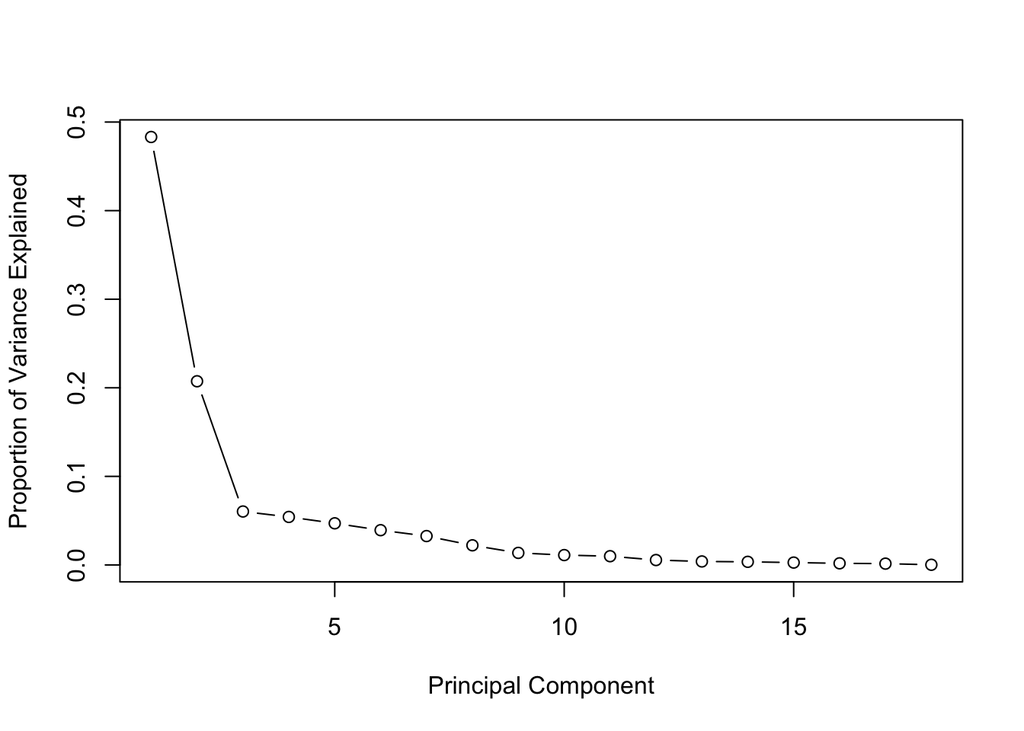

```r
### Calculate and display variance of components
PCA_var = (PCA$sdev)^2
prop_varex <- PCA_var/sum(PCA_var)

plot(prop_varex, xlab = "Principal Component",
     ylab = "Proportion of Variance Explained",
     type = "b")
```

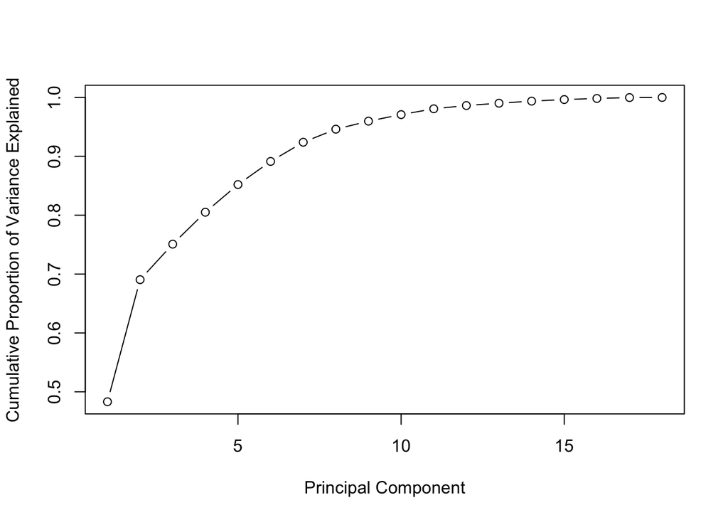

```r
plot(cumsum(prop_varex), xlab = "Principal Component",
     ylab = "Cumulative Proportion of Variance Explained",
     type = "b")
```

```r
### Based on analysis on plots above, we will select the 9 first PCA components
### Assesing communality of first 9 PCs:
communality <- rep(0,ncol(PCA$loadings))
NPCA <- 9

for(i in 1:NPCA) {
  communality <- communality + PCA$loadings[,i]^2
}

head(communality)
```

```
##       BEN        CO       EBE      NMHC        NO       NO2
## 0.1414968 0.1537279 0.6524383 0.9231054 0.1870077 0.1653393
```

```r
### Get a dataset with chosen PCAs and NO2 to create the linear regression on
PCAScores <- as.data.frame(PCA$scores[,1:9])
tolm <- cbind(avgByParameterAndDateWeather$NO2,PCAScores,avgByParameterAndDateWeather$date)
colnames(tolm)[1] = 'NO2'
colnames(tolm)[11] = 'date'

### Create a linear regression
lm4 <- lm(tolm$NO2 ~ tolm[,2]+tolm[,3]+tolm[,4]+tolm[,5]+tolm[,6]+tolm[,7]+tolm[,8]+tolm[,9]+tolm[,10], data=tolm)

### Calculate the fitted values for linear regression and add to previous dataset
lm_fit<-fitted(lm4)
tolm1<- cbind(tolm,lm_fit)
head(tolm1)
```

```
##        NO2      Comp.1    Comp.2     Comp.3     Comp.4      Comp.5
## 1 41.51042  1.38736003 -2.005201  0.1257966 -1.0227470 -1.19583436
## 2 48.47396  2.51940767 -1.706823 -0.4614927 -0.7234682 -1.32112682
## 3 63.63368  4.81682216 -1.409949 -0.1813118 -0.6839404 -0.89809862
## 4 46.29514  2.00257163 -2.212857  0.3901966 -0.5699942 -0.37877822
## 5 51.51736  2.43983339 -1.649140  0.5340762 -0.3358599  0.16103679
## 6 35.32812 -0.09430931 -2.226143  0.2872899 -0.2996523  0.07127005
##        Comp.6     Comp.7    Comp.8      Comp.9       date   lm_fit
## 1 -0.03079245 -0.8964088 0.2509840  0.10558940 2011-01-01 43.86703
## 2  0.01958572 -0.5281830 0.9418919 -0.59034013 2011-01-02 48.94669
## 3 -0.03572864 -0.3296162 0.2393189 -0.41719269 2011-01-03 62.29525
## 4  0.26287181 -1.1438912 0.3879337  0.13846889 2011-01-04 44.21953
## 5  0.12713571 -0.4317370 0.9562268 -0.07136077 2011-01-05 46.30095
## 6 -0.23837015 -0.2763409 1.5370779 -0.03207847 2011-01-06 30.99394
```

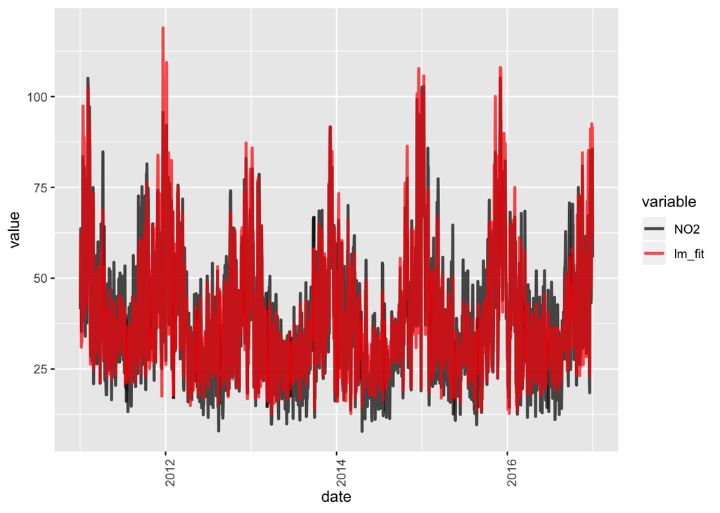

```r
### Melt previous dataset for plotting
metled_lm_fit <- melt(tolm1[, c('date','NO2','lm_fit')], id.vars='date')

ggplot(metled_lm_fit, aes(x=date, y=value, group=variable,colour=variable))+geom_line(lwd=1, alpha=0.7)+scale_color_manual(values=c('black','red'))+ theme(axis.text.x=element_text(angle=90))
```

```r
summary(lm4)
```

```
##
## Call:
## lm(formula = tolm$NO2 ~ tolm[, 2] + tolm[, 3] + tolm[, 4] + tolm[,
##     5] + tolm[, 6] + tolm[, 7] + tolm[, 8] + tolm[, 9] + tolm[,
##     10], data = tolm)
##
## Residuals:
##      Min       1Q   Median       3Q      Max
## -23.2570  -3.2324   0.0146   3.1729  15.9857
##
## Coefficients:
##             Estimate Std. Error t value Pr(>|t|)
## (Intercept) 38.82782    0.10404 373.189  < 2e-16 ***
## tolm[, 2]    5.29683    0.03528 150.131  < 2e-16 ***
## tolm[, 3]    2.09088    0.05385  38.827  < 2e-16 ***
## tolm[, 4]    0.20621    0.09983   2.066    0.039 *
## tolm[, 5]   -0.82131    0.10533  -7.798 9.69e-15 ***
## tolm[, 6]   -2.35569    0.11311 -20.826  < 2e-16 ***
## tolm[, 7]    1.14821    0.12378   9.277  < 2e-16 ***
## tolm[, 8]    1.83009    0.13581  13.476  < 2e-16 ***
## tolm[, 9]   -1.28641    0.16474  -7.809 8.88e-15 ***
## tolm[, 10]   1.88476    0.21005   8.973  < 2e-16 ***
## ---
## Signif. codes:  0 '***' 0.001 '**' 0.01 '*' 0.05 '.' 0.1 ' ' 1
##
## Residual standard error: 4.871 on 2182 degrees of freedom
## Multiple R-squared:  0.9196, Adjusted R-squared:  0.9193
## F-statistic:  2773 on 9 and 2182 DF,  p-value: < 2.2e-16
```